# HW7

Group 8

9 July 2024

Group:

Lisa Bensousan - 346462534 - lisa.bensoussan@mail.huji.ac.il  
Dan Levy - 346453202 - dan.levy5@mail.huji.ac.il  
Emmanuelle Fareau - 342687233 - emmanuel.fareau@mail.huji.ac.il

### Libraries used

```r
library(dplyr)
library(ggplot2)
library(splines)
library(data.table)
```

### Paths and Data

```r
cancer <- "/Users/Emmanuelle Fareau/Documents/Cours 2023-2024    (annee 4)/Maabada/TCGA-13-0723-01A_lib1_all_chr1.forward"
cancer = fread(cancer)
colnames(cancer) = c("Chrom","Loc","FragLen")
head(cancer)
```

```
##    Chrom   Loc FragLen
##    <int> <int>   <int>
## 1:     1    28     153
## 2:     1    35     184
## 3:     1    35     177
## 4:     1    36     186
## 5:     1    37       0
## 6:     1    37     242
```

```r
healthy <- "/Users/Emmanuelle Fareau/Documents/Cours 2023-2024    (annee 4)/Maabada/TCGA-13-0723-10B_lib1_all_chr1.forward.gz"
healthy = fread(healthy)
colnames(healthy) = c("Chrom","Loc","FragLen")
head(healthy)
```

```
##    Chrom   Loc FragLen
##    <int> <int>   <int>
## 1:     1    24     105
## 2:     1    24     122
## 3:     1    24     108
## 4:     1    30     142
## 5:     1    33     107
## 6:     1    33     229
```

```r
load("C:/Users/Emmanuelle Fareau/Downloads/chr1_str_30M_50M.rda")

load("/Users/Emmanuelle Fareau/Downloads/GC_100.rda")
load("/Users/Emmanuelle Fareau/Downloads/reads_100_B1.rda")
load("/Users/Emmanuelle Fareau/Downloads/reads_100_A1.rda")
load("/Users/Emmanuelle Fareau/Downloads/chr1_line.rda")

fname= "/Users/Emmanuelle Fareau/Downloads/reads_gc_5K.rda"
load(fname)




# cancer <- "/Users/lisabensoussan/Desktop/Lab7/TCGA-13-0723-01A_lib1_all_chr1.forward"
# cancer = fread(cancer)
# colnames(cancer) = c("Chrom","Loc","FragLen")
# head(cancer)
#
# healthy <- "/Users/lisabensoussan/Desktop/Lab7/TCGA-13-0723-10B_lib1_all_chr1.forward"
# healthy = fread(healthy)
# colnames(healthy) = c("Chrom","Loc","FragLen")
# head(healthy)
# load("/Users/lisabensoussan/Desktop/Lab7/GC_100.rda")
# load("/Users/lisabensoussan/Desktop/Lab7/reads_100_B1.rda")
# load("/Users/lisabensoussan/Desktop/Lab7/reads_100_A1.rda")
#
# load("/Users/lisabensoussan/Desktop/Lab7/chr1_line.rda")
# load("/Users/lisabensoussan/Desktop/Lab7/reads_gc_5K.rda")
# load("/Users/lisabensoussan/Desktop/Lab7/chr1_str_30M_50M.rda")


#PATHS OF DAN :

# cancer <- "/Users/danlevy/Desktop/TCGA-13-0723-01A_lib1_all_chr1.forward (2)"
# cancer = fread(cancer)
# colnames(cancer) = c("Chrom","Loc","FragLen")
# head(cancer)
#
# healthy <- "/Users/danlevy/Desktop/TCGA-13-0723-10B_lib1_all_chr1.forward"
# healthy = fread(healthy)
# colnames(healthy) = c("Chrom","Loc","FragLen")
# head(healthy)
```

## Introduction

In this lab, we will examine the distribution of GC bases across DNA segments and compare the different samples using regression splines and other statistical tools.

## Preliminary part

We prepare our data by calculating the number of GCs, and the number of fragments by performing spline regression for each cancer and healthy data.

```r
sequence <- chr1_str_30M_50M
sequence <- strsplit(sequence, "")
sequence <- sequence[[1]]

frag_cancer <- as.numeric(cancer$FragLen)
frag_healthy <- as.numeric(healthy$FragLen)

segment_length <- 10000
num_segments <- length(sequence)/10000

segments <- split(sequence, rep(1:num_segments, each = segment_length, length.out = length(sequence)))


calculate_gc_content <- function(seq) {
  gc_count <- sum(seq == "G" | seq == "C")
  return(gc_count)
}

gc_contents <- sapply(segments, calculate_gc_content)
head(gc_contents)
```

```
##    1    2    3    4    5    6
## 4966 3604 4075 5110 4911 4993
```

```r
count_fragment_starts <- function(data, chrom_number, start_range, end_range) {
  relevant_data <- data[Chrom == chrom_number & Loc >= start_range & Loc <= end_range,]
  start_counts <- integer(end_range - start_range + 1)
  names(start_counts) <- as.character(start_range:end_range)

  starts <- table(relevant_data$Loc)

  start_positions <- as.character(names(starts))
  start_counts[start_positions] <- as.integer(starts)

  return(start_counts)
}

fragment_counts_cancer <- count_fragment_starts(cancer, 1, 0, 20000000)
fragment_counts_healthy <- count_fragment_starts(healthy, 1, 0, 20000000)



sum_frag_cancer <- numeric(length = length(fragment_counts_cancer) / 10000)


for (i in seq(1, length(fragment_counts_cancer), by = 10000)) {
  group_index <- (i - 1) / 10000
  sum_frag_cancer[group_index] <- sum(fragment_counts_cancer[i:(i+9999)])
}


head(sum_frag_cancer)
```

```
## [1] 36 22 17 58 42 53
```

```r
sum_frag_healthy <- numeric(length = length(fragment_counts_healthy) / 10000)


for (i in seq(1, length(fragment_counts_healthy), by = 10000)) {
  group_index <- (i - 1) / 10000
  sum_frag_healthy[group_index] <- sum(fragment_counts_healthy[i:(i+9999)])
}


head(sum_frag_healthy)
```

```
## [1] 30 43 29 66 73 69
```

```r
data <- data.frame(gc_count = gc_contents, fragment_cancer = sum_frag_cancer, fragment_healthy = sum_frag_healthy)

knots <- quantile(data$gc_count, probs = c(0.25, 0.5, 0.75))

model_cancer <- lm(fragment_cancer ~ ns(gc_count, knots = knots), data = data)
model_healty <- lm(fragment_healthy ~ ns(gc_count, knots = knots), data = data)

print(summary(model_cancer))
```

```
##
## Call:
## lm(formula = fragment_cancer ~ ns(gc_count, knots = knots), data = data)
##
## Residuals:
##     Min      1Q  Median      3Q     Max
## -716.73  -55.45   60.91  127.34 1750.62
##
## Coefficients:
##                              Estimate Std. Error t value Pr(>|t|)
## (Intercept)                    766.11      66.87  11.457   <2e-16 ***
## ns(gc_count, knots = knots)1   -93.86      62.15  -1.510   0.1311
## ns(gc_count, knots = knots)2  -108.27      47.76  -2.267   0.0235 *
## ns(gc_count, knots = knots)3  -141.93     146.61  -0.968   0.3331
## ns(gc_count, knots = knots)4   -22.50      50.59  -0.445   0.6566
## ---
## Signif. codes:  0 '***' 0.001 '**' 0.01 '*' 0.05 '.' 0.1 ' ' 1
##
## Residual standard error: 258 on 1994 degrees of freedom
##   (1 observation effacée parce que manquante)
## Multiple R-squared:  0.007196,   Adjusted R-squared:  0.005204
## F-statistic: 3.613 on 4 and 1994 DF,  p-value: 0.006101
```

```r
print(summary(model_healty))
```

```
##
## Call:
## lm(formula = fragment_healthy ~ ns(gc_count, knots = knots),
##     data = data)
##
## Residuals:
##     Min      1Q  Median      3Q     Max
## -785.40  -43.93   55.42  132.20 2272.36
##
## Coefficients:
##                              Estimate Std. Error t value Pr(>|t|)
## (Intercept)                    904.98      70.07  12.916  < 2e-16 ***
## ns(gc_count, knots = knots)1  -188.66      65.12  -2.897 0.003810 **
## ns(gc_count, knots = knots)2  -165.55      50.05  -3.308 0.000956 ***
## ns(gc_count, knots = knots)3  -335.60     153.62  -2.185 0.029041 *
## ns(gc_count, knots = knots)4   -95.07      53.01  -1.793 0.073061 .
## ---
## Signif. codes:  0 '***' 0.001 '**' 0.01 '*' 0.05 '.' 0.1 ' ' 1
##
## Residual standard error: 270.3 on 1994 degrees of freedom
##   (1 observation effacée parce que manquante)
## Multiple R-squared:  0.01381,    Adjusted R-squared:  0.01183
## F-statistic: 6.979 on 4 and 1994 DF,  p-value: 1.411e-05
```

We draw graphs to better visualize our data.

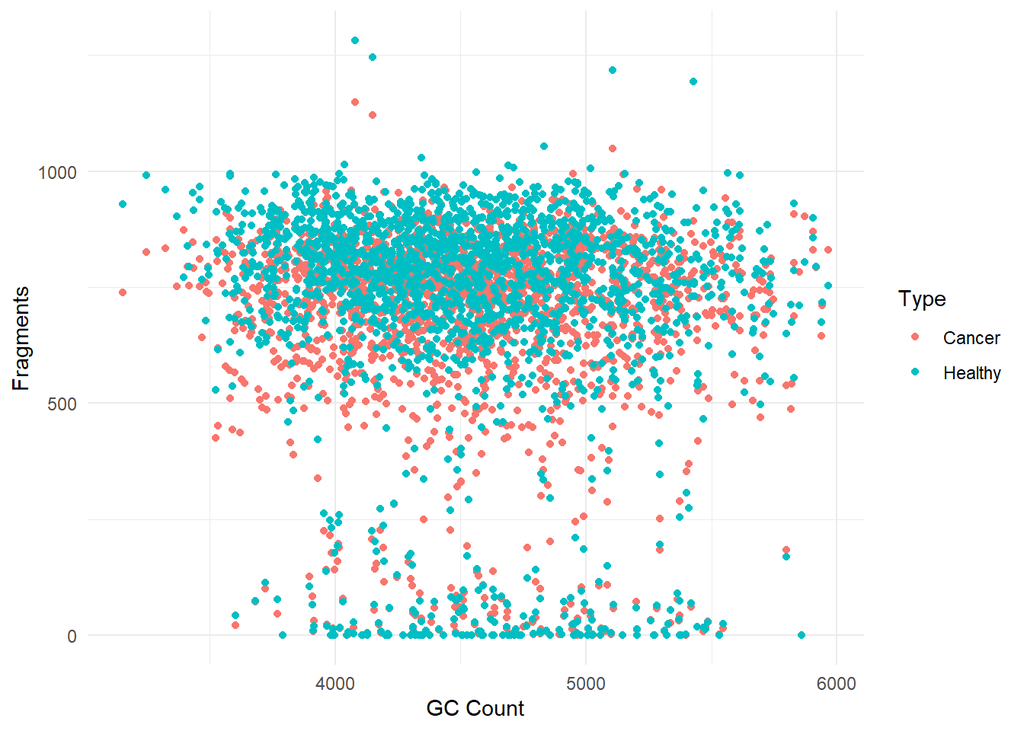

```r
threshold_cancer <- quantile(data$fragment_cancer, 0.99, na.rm = TRUE)
threshold_healthy <- quantile(data$fragment_healthy, 0.99, na.rm = TRUE)



filtered_data <- data %>%
  filter(fragment_cancer <= threshold_cancer & fragment_healthy <= threshold_healthy)

ggplot(filtered_data, aes(x = gc_count)) +
  geom_point(aes(y = fragment_cancer, color = "Cancer")) +
  geom_point(aes(y = fragment_healthy, color = "Healthy")) +
  labs(x = "GC Count", y = "Fragments", color = "Type") +
  theme_minimal()
```

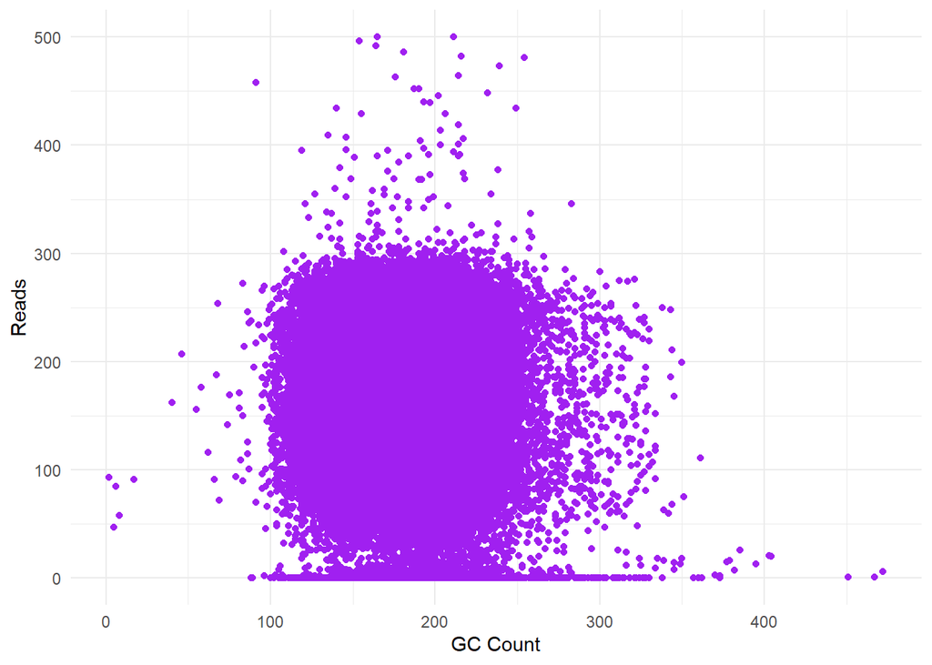

```r
reads_5K <- as.numeric(reads_5K)

segment_length <- floor(length(sequence) / length(reads_5K))
num_segments <- length(reads_5K)

segments <- split(sequence, rep(1:num_segments, each = segment_length, length.out = length(sequence)))

calculate_gc_content <- function(seq) {
  gc_count <- sum(seq == "G" | seq == "C")
  return(gc_count)
}


gc_contents <- sapply(segments, calculate_gc_content)


stopifnot(length(gc_contents) == length(reads_5K))

data_essai <- data.frame(gc_content = gc_contents, coverage = reads_5K)
data_essai <- na.omit(data_essai)

remove_outliers <- function(data) {
  model <- lm(coverage ~ poly(gc_content, 3), data = data)
  residuals <- residuals(model)
  data$residuals <- residuals
  threshold <- 3 * sd(data$residuals, na.rm = TRUE)

  cleaned_data <- data %>%
    filter(abs(residuals) <= threshold)

  return(cleaned_data)
}

data_essai <- remove_outliers(data_essai)

ggplot(data_essai, aes(x = gc_content)) +
  geom_point(aes(y = coverage), color = 'purple') +
  labs(x = "GC Count", y = "Reads") +
  ylim(0,500)+
  theme_minimal()
```

```r
sequence <- chr1_line
sequence <- as.character(sequence)

reads_cancer <- as.numeric(reads_100_A1)
reads_healthy <- as.numeric(reads_100_B1)
```

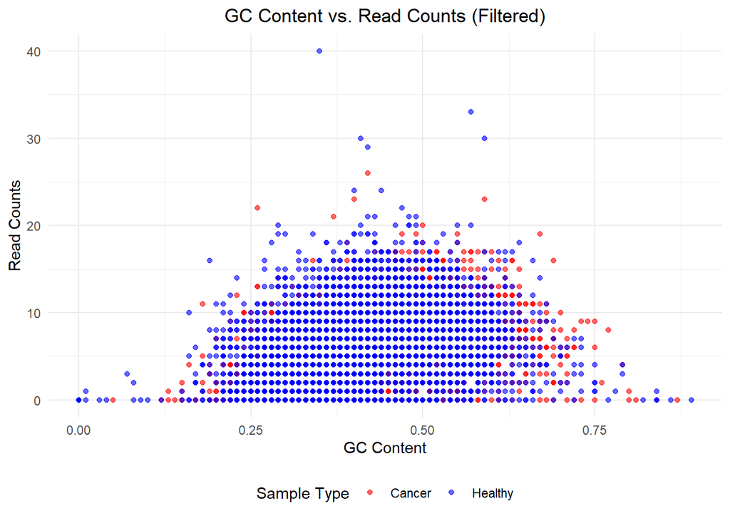

```r
set.seed(50)  # For reproducibility in sampling

sample_indices_cancer <- sample(seq_along(reads_100_A1), 5000)
sample_indices_healthy <- sample(seq_along(reads_100_B1), 5000)

plot_data <- data.frame(
  GC_100 = c(GC_100[sample_indices_cancer], GC_100[sample_indices_healthy]),
  Reads = c(reads_100_A1[sample_indices_cancer], reads_100_B1[sample_indices_healthy]),
  Type = rep(c("Cancer", "Healthy"), each = 5000)
)

plot_data <- na.omit(plot_data)
plot_data <- plot_data[plot_data$Reads <= 100, ]

ggplot(plot_data, aes(x = GC_100, y = Reads, color = Type)) +
  geom_point(alpha = 0.6) +
  labs(
    title = "GC Content vs. Read Counts (Filtered)",
    x = "GC Content",
    y = "Read Counts",
    color = "Sample Type"
  ) +
  theme_minimal() +
  theme(
    plot.title = element_text(hjust = 0.5),  # Center the title
    legend.position = "bottom"
  ) +
  scale_color_manual(values = c("Cancer" = "red", "Healthy" = "blue"))  # Define custom colors for the groups
```

With all these values and data, we can now work in lab.

## Part 1

### א :

Total variance formula :

$$Var(Y)=E(Var(\frac{Y}{GC}))+Var(E(\frac{Y}{GC}))$$

We creataed 2 new datasets, one for cancer and one for healthy in subsetting ‘plot_data’ such that’data_cancer’ will only include rows where the Type column equals “Cancer” ‘data_healthy’ will only include rows where the Type column equals “Healthy”.

```r
data_cancer <- subset(plot_data, plot_data$Type == "Cancer")
data_healthy <- subset(plot_data, plot_data$Type == "Healthy")
```

We then calculate the median and the interquartile range (IQR) of the read counts for healthy data. These statistics are used to define a range for filtering outliers. We consider that reads that are below the lower bound or above the upper bound are considered outliers. Finally we filter out outlier reads from the healthy dataset such that ‘healthy_data_filtered’ will only include reads within the specified range.

```r
# Calculating median and IQR
median_reads <- median(data_healthy$Reads)
IQR_reads <- IQR(data_healthy$Reads)
lower_bound <- median_reads - 1.5 * IQR_reads
upper_bound <- median_reads + 1.5 * IQR_reads

# Filtering outliers based on these bounds
healthy_data_filtered <- data_healthy %>%
  filter(Reads >= lower_bound & Reads <= upper_bound)
```

We fit a Poisson regression model to the filtered healthy data and calculate the expected reads for each data point in the healthy filtered dataset using the fitted model.

```r
# Fit Poisson model
model_poisson <- glm(Reads ~ GC_100, family = poisson(), data = healthy_data_filtered)

# Calculate expected reads
healthy_data_filtered$expected_reads <- predict(model_poisson, type = "response")
```

We analyze the variance in read counts from a filtered healthy dataset using a Poisson regression model. This model estimates read counts based on GC content, where the expected variance from the model equates to the mean of the predicted reads, reflecting how well GC content explains read variability. Additionally, we calculated the variance of these predictions and the residual variance to quantify the unexplained portion of the total variance. The results are then expressed as percentages, highlighting the proportion of variance explained by the Poisson model, the impact of GC content, and the unexplained variance, providing a clear picture of the model’s explanatory power and its limitations.

```r
# Total observed variance
total_variance <- var(healthy_data_filtered$Reads)

# Variance due to the Poisson model (since Var(Y|X) = E(Y|X) for a Poisson)
expected_variance_due_to_poisson <- mean(healthy_data_filtered$expected_reads)

# Variance of expected values (how much variance is explained by the GC effect alone)
variance_of_expected_values <- var(healthy_data_filtered$expected_reads)



# Calculate residual variance (unexplained variance)
unexplained_variance <- total_variance - (expected_variance_due_to_poisson + variance_of_expected_values)

percentage_due_to_poisson <- 100 * expected_variance_due_to_poisson / total_variance
percentage_due_to_gc_effect <- 100 * variance_of_expected_values / total_variance
percentage_unexplained <- 100 - (percentage_due_to_poisson + percentage_due_to_gc_effect)

cat("Percentage of variance in the healthy sample due to the Poisson distribution: ", percentage_due_to_poisson, "%\n")
```

```
## Percentage of variance in the healthy sample due to the Poisson distribution:  32.26796 %
```

```r
cat("Percentage of the variation in the sample due to the GC effect: ", percentage_due_to_gc_effect, "%\n")
```

```
## Percentage of the variation in the sample due to the GC effect:  27.55354 %
```

```r
cat("Percentage of the variation not explained by these factors: ", percentage_unexplained, "%\n")
```

```
## Percentage of the variation not explained by these factors:  40.1785 %
```

## Part 2

A regression is performed in both the cancer sample and the saint sample. We want to compare these two models.

### ב :

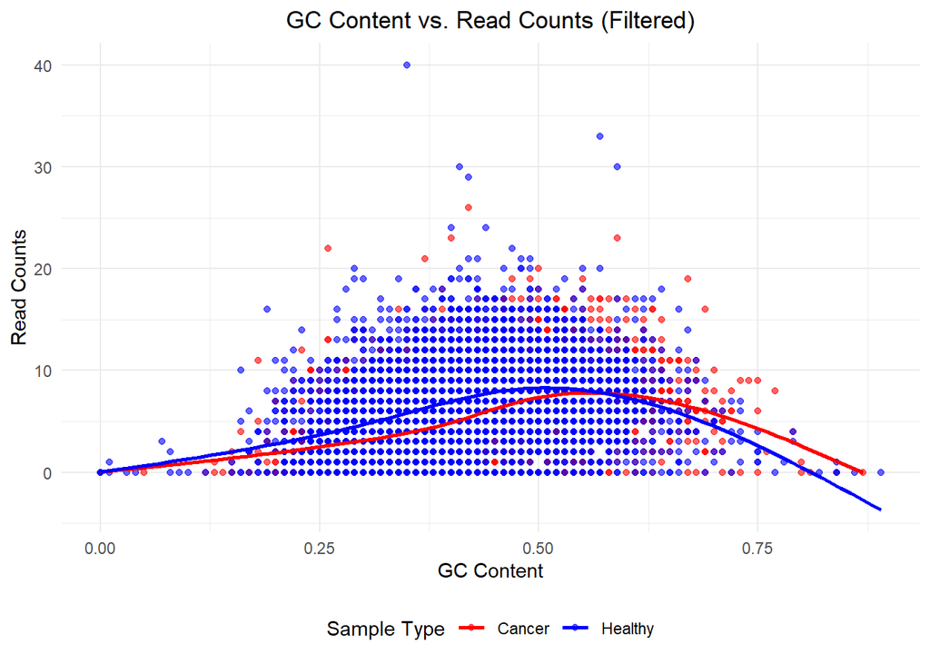

```r
ggplot(plot_data, aes(x = GC_100, y = Reads, color = Type)) +
  geom_point(alpha = 0.6) +  # Using semi-transparent points to handle overlap visually
  geom_smooth(method = "lm", formula = y ~ splines::ns(x, df = 4),   # Add spline regression line with 4 degrees of freedom
              se = FALSE, aes(color = Type), size = 1) +  # 'se = FALSE' removes the confidence interval shading
  labs(
    title = "GC Content vs. Read Counts (Filtered)",
    x = "GC Content",
    y = "Read Counts",
    color = "Sample Type"
  ) +
  theme_minimal() +
  theme(
    plot.title = element_text(hjust = 0.5),  # Center the title
    legend.position = "bottom"
  ) +
  scale_color_manual(values = c("Cancer" = "red", "Healthy" = "blue"))  # Define custom colors for the groups
```

Yes there is a correlation between GC with reads, and we can see that the two regressions are similar but not equals.

### ג :

#### a :

In the provided R script, we first set up regression models for cancer and healthy datasets, using natural splines to model the relationship between reads and GC content, with knots placed at the quartiles of the GC content distribution. After cleaning the data of missing values, we fit separate linear models for each dataset. A custom function, `estimate_copy_number`, then uses these models to estimate copy numbers by dividing observed reads by the model-predicted factor, effectively normalizing read counts based on GC content. These estimated copy numbers are then plotted against their genome index and GC content to visualize the distribution and relationship of estimated copy numbers across the genome for both cancer and healthy samples, highlighting differences and similarities in copy number variation driven by genomic content.

```r
knots <- quantile(data_cancer$GC_100, probs = c(0.25, 0.5, 0.75))

data_cancer <- na.omit(data_cancer)
data_healthy <- na.omit(data_healthy)


model_cancer <- lm(Reads ~ ns(GC_100, knots = knots), data = data_cancer)
model_healthy <- lm(Reads ~ ns(GC_100, knots = knots), data = data_healthy)

estimate_copy_number <- function(Y, GC, model) {
  # Ensure GC is named correctly according to the model's expectation
  f_gc_hat <- predict(model, newdata = data.frame(GC_100 = GC))
  a_hat <- Y / f_gc_hat
  return(a_hat)
}

#apply the function to our cancer  data
Y_cancer <- data_cancer$Reads
GC_cancer<- data_cancer$GC_100

#apply the function to our healthy  data
Y_healthy <- data_healthy$Reads
GC_healthy<- data_healthy$GC_100

# Calculate estimated copy numbers
estimated_copy_numbers_cancer <- estimate_copy_number(Y_cancer, GC_cancer, model_cancer)
estimated_copy_numbers_healthy<- estimate_copy_number(Y_healthy, GC_healthy, model_healthy)


head(estimated_copy_numbers_cancer)
```

```
##         1         2         3         4         5         6
## 0.8671686 0.2263302 2.5882944 0.0000000 0.0000000 0.8111963
```

```r
head(estimated_copy_numbers_healthy)
```

```
##         1         2         3         4         5         6
## 0.3959158 0.2034924 1.4782887 0.0000000 1.6080526 0.6457624
```

We plot of the number of copies along the chromosome.

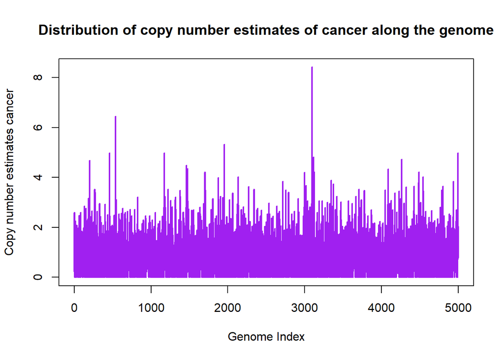

```r
data_cancer$estimated_copies_cancer <- estimated_copy_numbers_cancer


plot(estimated_copy_numbers_cancer, type = "l", main = "Distribution of copy number estimates of cancer along the genome",
     xlab = "Genome Index", ylab = "Copy number estimates cancer", col = "purple", lwd = 2)
```

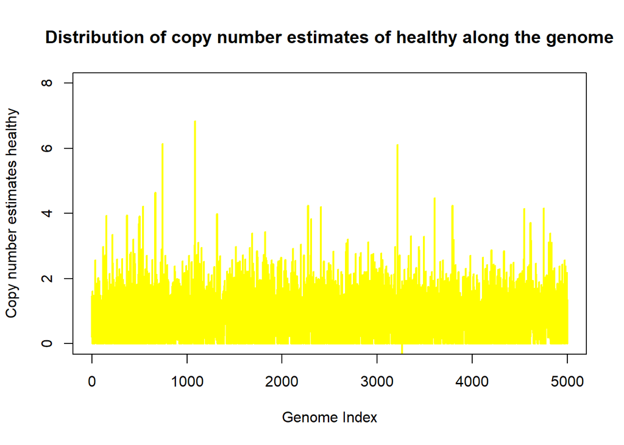

```r
data_healthy$estimated_copies_healthy <- estimated_copy_numbers_healthy


plot(estimated_copy_numbers_healthy, type = "l", main = "Distribution of copy number estimates of healthy along the genome",
     xlab = "Genome Index", ylab = "Copy number estimates healthy", col = "yellow", lwd = 2,, ylim = c(0,8))
```

We visualize the relationship between GC content and estimated copies.

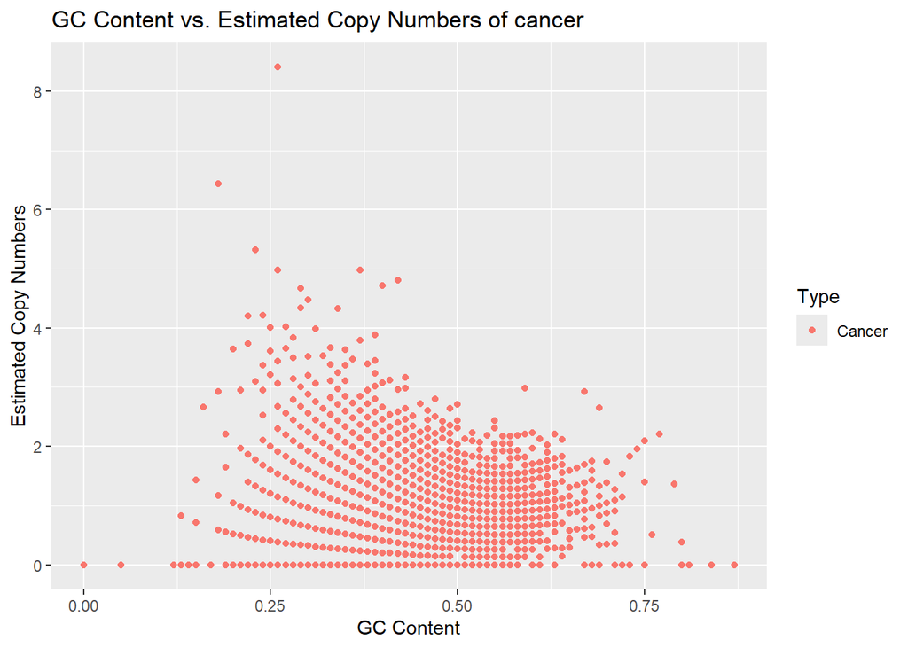

```r
ggplot(data_cancer, aes(x = GC_100, y = estimated_copies_cancer, color = Type)) +
  geom_point() +
  labs(title = "GC Content vs. Estimated Copy Numbers of cancer",
       x = "GC Content",
       y = "Estimated Copy Numbers")
```

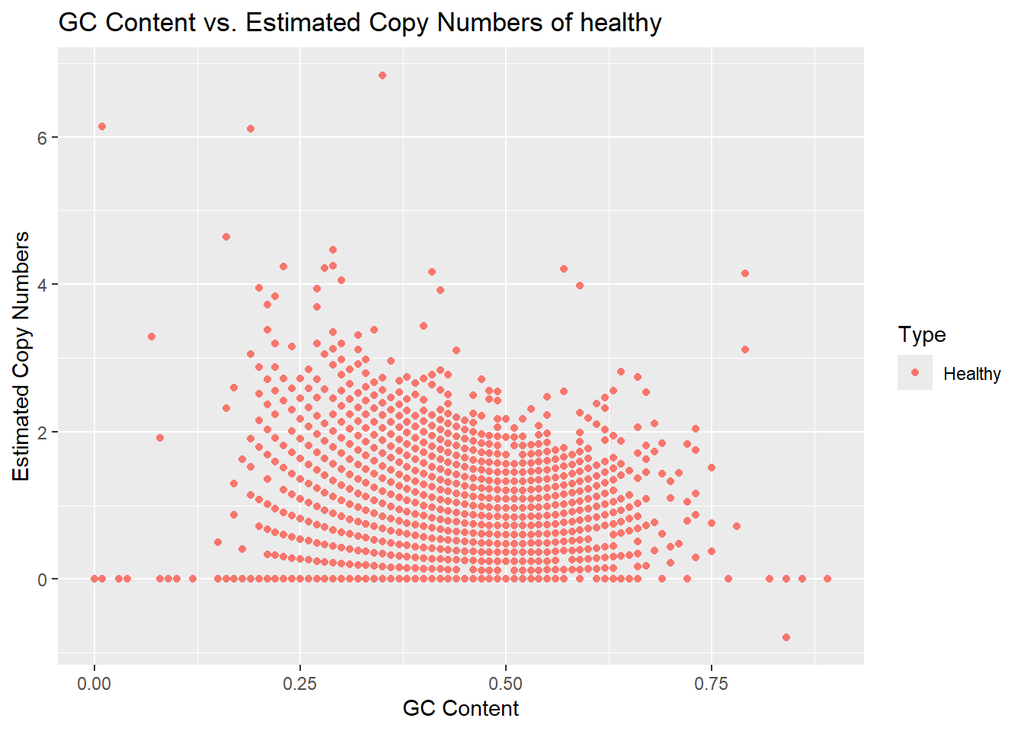

```r
ggplot(data_healthy, aes(x = GC_100, y = estimated_copies_healthy, color = Type)) +
  geom_point() +
  labs(title = "GC Content vs. Estimated Copy Numbers of healthy",
       x = "GC Content",
       y = "Estimated Copy Numbers")
```

##### for cancer:

In this R scripts, we first calculate the median and interquartile range (IQR) for the reads from both cancer and healthy datasets to determine bounds for filtering outliers. Data points falling outside 1.5 times the IQR from the median are considered outliers and are removed, creating a filtered subset for each dataset. We then visualize the relationship between reads and estimated copy numbers, comparing data before and after outlier removal. Scatter plots are generated for both datasets, highlighting differences using color-coded points, and legends are added to distinguish between unfiltered and filtered data, providing a clear visual representation of the impact of outlier correction on the estimated copy numbers.

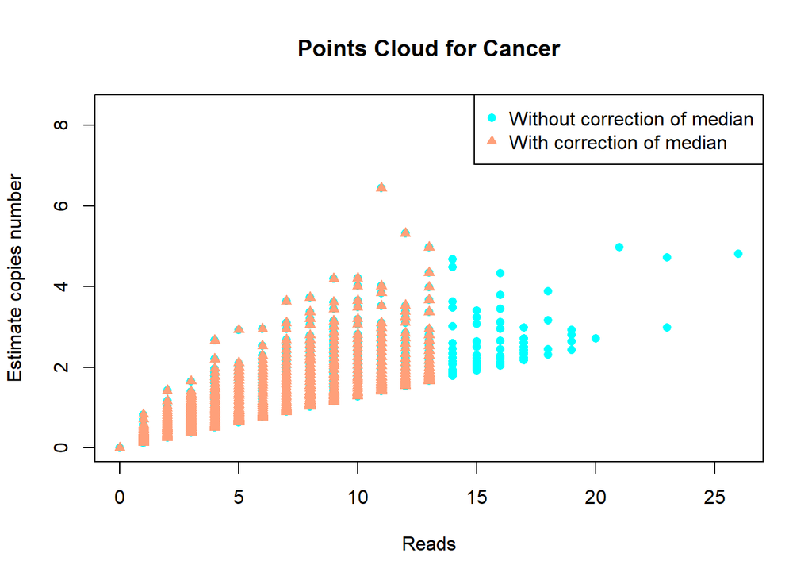

```r
median_reads_cancer <- median(data_cancer$Reads)
IQR_reads_cancer <- IQR(data_cancer$Reads)
lower_bound_cancer <- median_reads_cancer - 1.5 * IQR_reads_cancer
upper_bound_cancer <- median_reads_cancer + 1.5 * IQR_reads_cancer

data_cancer_filtered <- data_cancer %>%
  filter(Reads >= lower_bound_cancer & Reads <= upper_bound_cancer)



plot(data_cancer$Reads,data_cancer$estimated_copies_cancer,
     col = "cyan",
     pch = 16,
     xlab = "Reads",
     ylab = "Estimate copies number",
     main = "Points Cloud for Cancer",
     xlim = range(c(data_cancer$Reads, data_cancer_filtered$Reads)),
     ylim = range(c(data_cancer$estimated_copies_cancer, data_cancer_filtered$estimated_copies_cancer)))

points(data_cancer_filtered$Reads, data_cancer_filtered$estimated_copies_cancer,
       col = "lightsalmon",
       pch = 17)

legend("topright", legend = c("Without correction of median", "With correction of median"),
       col = c("cyan", "lightsalmon"), pch = c(16, 17))
```

##### for healthy:

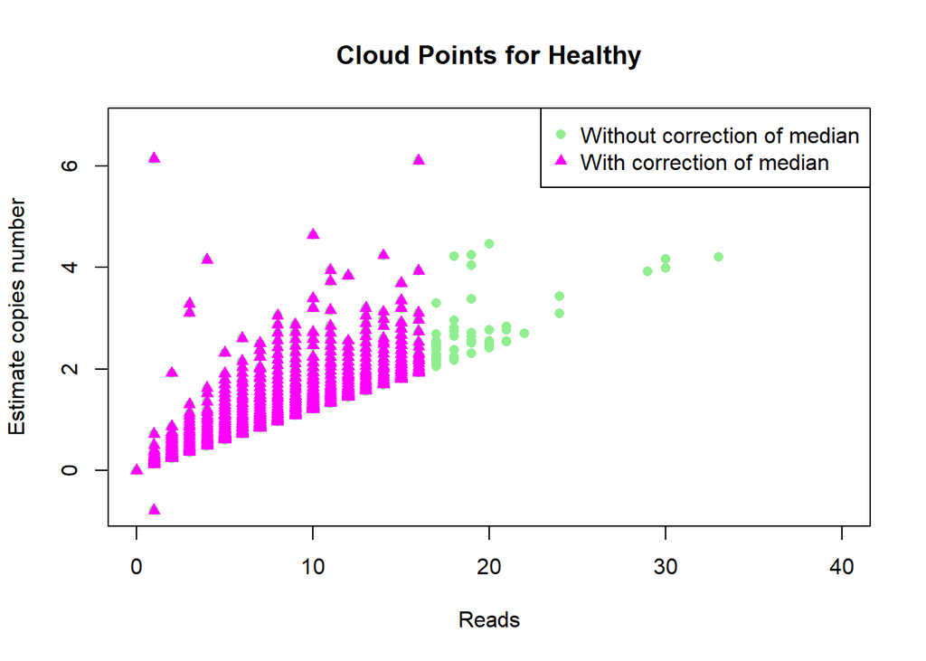

```r
median_reads_healthy <- median(data_healthy$Reads)
IQR_reads_healthy <- IQR(data_healthy$Reads)
lower_bound_healthy <- median_reads_healthy - 1.5 * IQR_reads_healthy
upper_bound_healthy <- median_reads_healthy + 1.5 * IQR_reads_healthy

data_healthy_filtered <- data_healthy %>%
  filter(Reads >= lower_bound_healthy & Reads <= upper_bound_healthy)



plot(data_healthy$Reads,data_healthy$estimated_copies_healthy,
     col = "lightgreen",
     pch = 16,
     xlab = "Reads",
     ylab = "Estimate copies number",
     main = "Cloud Points for Healthy",
     xlim = range(c(data_healthy$Reads, data_healthy_filtered$Reads)),
     ylim = range(c(data_healthy$estimated_copies_healthy, data_healthy_filtered$estimated_copies_healthy)))

points(data_healthy_filtered$Reads, data_healthy_filtered$estimated_copies_healthy,
       col = "magenta",
       pch = 17)

legend("topright", legend = c("Without correction of median", "With correction of median"),
       col = c("lightgreen", "magenta"), pch = c(16, 17))
```

We standardize the value in the sample to see if there is a improved quality of estimators.

```r
first_column <- data_healthy[[1]]
mean_first_column <- mean(first_column, na.rm = TRUE)
sd_first_column <- sd(first_column, na.rm = TRUE)
standardized_first_column <- (first_column - mean_first_column) / sd_first_column
data_healthy$new_gc_healthy <- standardized_first_column
cat("First few standardized values in the new 'new_gc' column:\n")
```

```
## First few standardized values in the new 'new_gc' column:
```

```r
print(head(data_healthy$new_gc_healthy))
```

```
## [1]  0.35263825 -0.40178627 -0.08744272 -2.35071628  1.10706277  0.41550696
```

We do the same as previous for the cancer data.

```r
first_column <- data_cancer[[1]]
mean_first_column <- mean(first_column, na.rm = TRUE)
sd_first_column <- sd(first_column, na.rm = TRUE)
standardized_first_column <- (first_column - mean_first_column) / sd_first_column
data_cancer$new_gc_cancer <- standardized_first_column
cat("First few standardized values in the new 'new_gc' column:\n")
```

```
## First few standardized values in the new 'new_gc' column:
```

```r
print(head(data_cancer$new_gc_cancer))
```

```
## [1]  2.045633016 -0.005346434  0.251025997  1.212422614 -0.582184405
## [6] -0.261718866
```

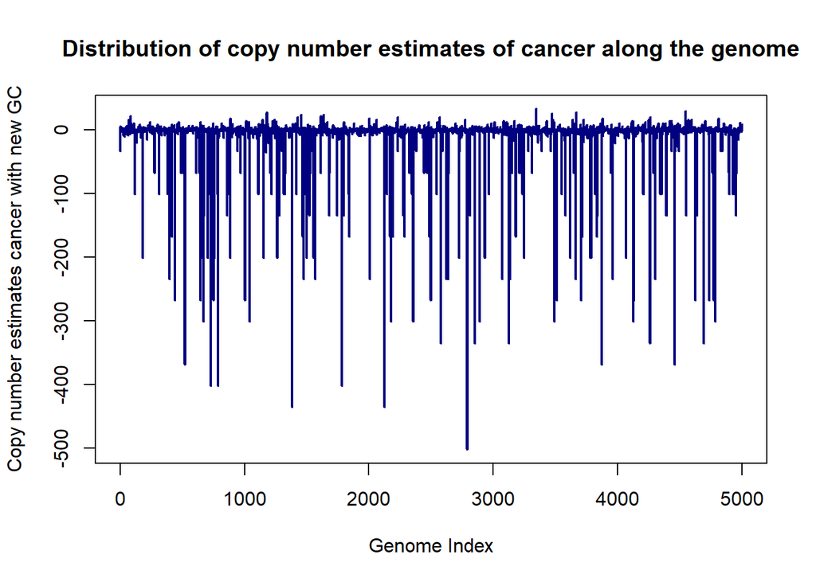

```r
model_cancer_new <- lm(Reads ~ ns(GC_100, knots = knots), data = data_cancer)
model_healthy_new <- lm(Reads ~ ns(GC_100, knots = knots), data = data_healthy)

GC_cancer_new<- data_cancer$new_gc_cancer


GC_healthy_new<- data_healthy$new_gc_healthy


estimated_copy_numbers_cancer_new <- estimate_copy_number(Y_cancer, GC_cancer_new, model_cancer_new)
estimated_copy_numbers_healthy_new<- estimate_copy_number(Y_healthy, GC_healthy_new, model_healthy_new)



data_cancer$estimated_copies_cancer_new <- estimated_copy_numbers_cancer_new


plot(estimated_copy_numbers_cancer_new, type = "l", main = "Distribution of copy number estimates of cancer along the genome",
     xlab = "Genome Index", ylab = "Copy number estimates cancer with new GC", col = "navy", lwd = 2)
```

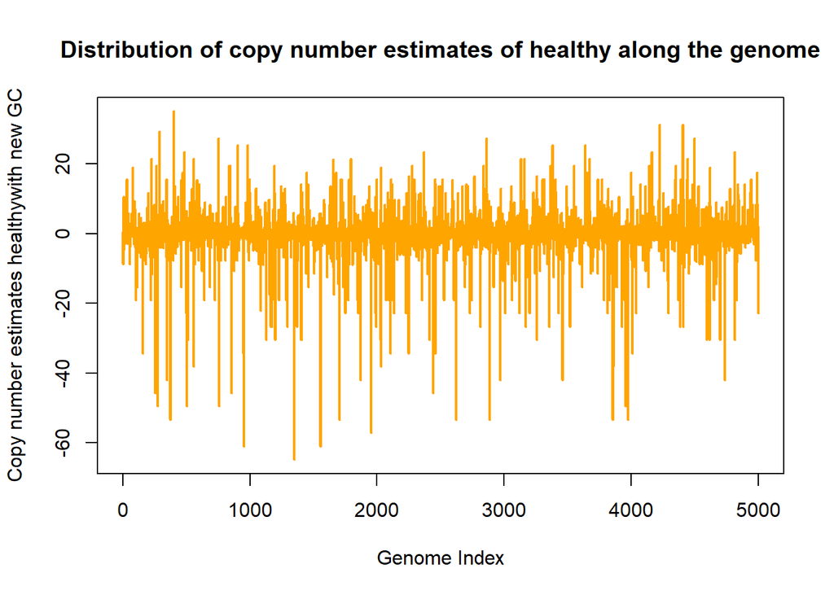

```r
data_healthy$estimated_copies_healthy_new <- estimated_copy_numbers_healthy_new


plot(estimated_copy_numbers_healthy_new, type = "l", main = "Distribution of copy number estimates of healthy along the genome",
     xlab = "Genome Index", ylab = "Copy number estimates healthywith new GC", col = "orange", lwd = 2)
```

### b :

We are looking to the copy number in the cancer data.

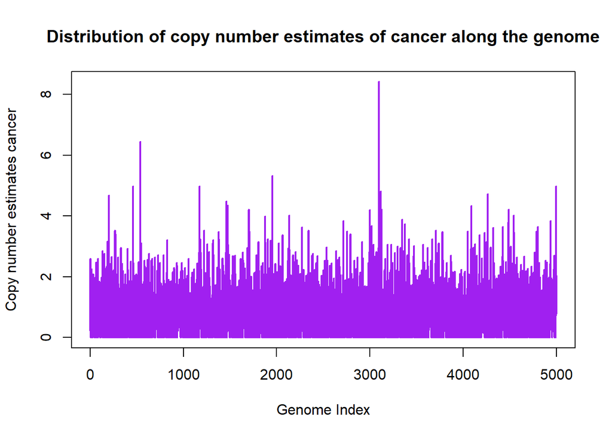

```r
plot(estimated_copy_numbers_cancer, type = "l", main = "Distribution of copy number estimates of cancer along the genome",
     xlab = "Genome Index", ylab = "Copy number estimates cancer", col = "purple", lwd = 2)
```

This variation may be due to different factors, such as specific regions of the genome that are more likely to be amplified or deleted in cancer cells.

### c :

We now want to compare it to data healthy. To do this we will represent the estimated number of copies along the cancer and healthy genome at the same time to be able to compare them to each other.

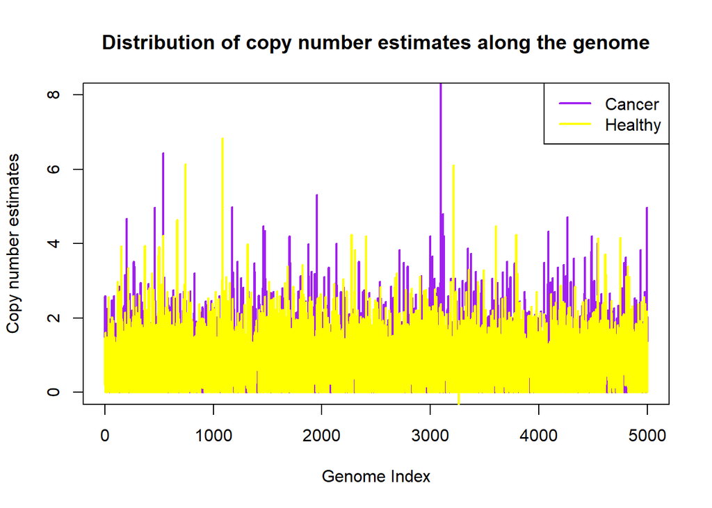

```r
y_limits <- c(0, 8)

plot(estimated_copy_numbers_cancer, type = "l",
     main = "Distribution of copy number estimates along the genome",
     xlab = "Genome Index", ylab = "Copy number estimates",
     col = "purple", lwd = 2, ylim = y_limits)

lines(estimated_copy_numbers_healthy, type = "l",
      col = "yellow", lwd = 2)

legend("topright", legend = c("Cancer", "Healthy"),
       col = c("purple", "yellow"), lwd = 2)
```

The two distributions show some similarity in general trends, with variations along the genome. However, the peaks for cancer are more pronounced, indicating segments of the genome with much higher copy levels.

### d :

To do this question, we need to have a data with the estimated copies of cancer and healthy.

We create a graph with on the x-axis the estimated number of healthy copies and on the y-axis the estimated number of cancer copies.

```r
data_cancer$estimated_copies_healthy <- NA
data_healthy$estimated_copies_cancer <- NA

cols_to_keep <- c("GC_100", "Reads", "Type", "estimated_copies_healthy", "estimated_copies_cancer")

data_cancer_subset <- data_cancer[, cols_to_keep]
data_healthy_subset <- data_healthy[, cols_to_keep]

data_cancer_subset[is.na(data_cancer_subset)] <- 0
data_healthy_subset[is.na(data_healthy_subset)] <- 0

combined_data <- rbind(data_cancer_subset, data_healthy_subset)

head(combined_data)
```

```
##   GC_100 Reads   Type estimated_copies_healthy estimated_copies_cancer
## 1   0.70     5 Cancer                        0               0.8671686
## 2   0.38     1 Cancer                        0               0.2263302
## 3   0.42    14 Cancer                        0               2.5882944
## 4   0.57     0 Cancer                        0               0.0000000
## 5   0.29     0 Cancer                        0               0.0000000
## 6   0.34     3 Cancer                        0               0.8111963
```

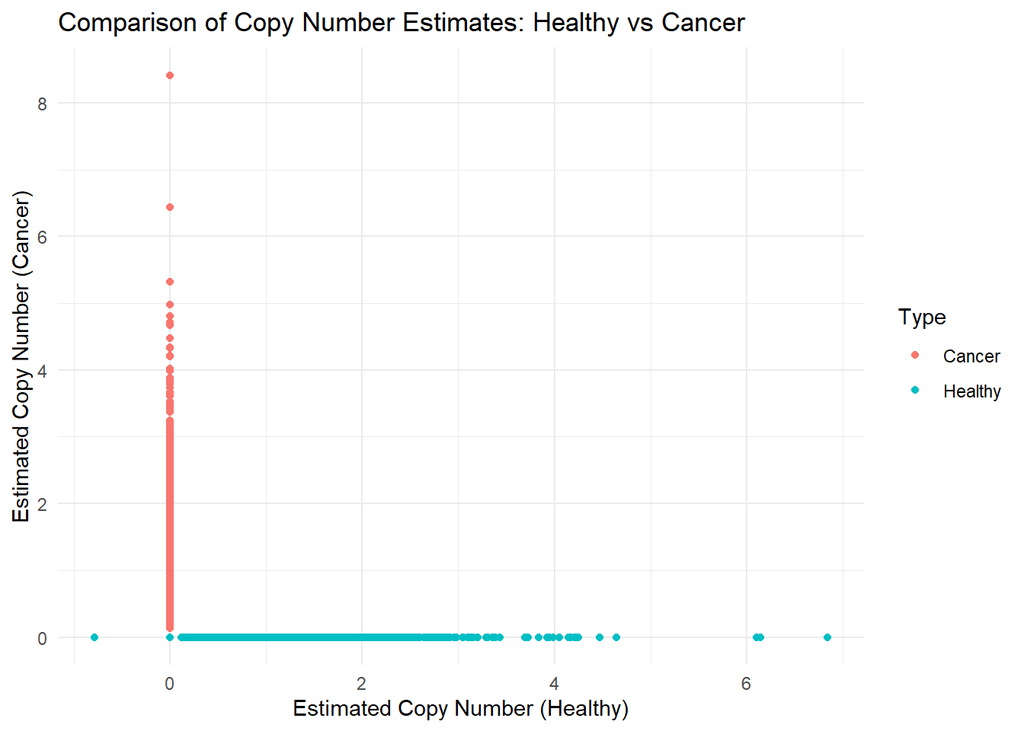

```r
ggplot(combined_data, aes(x = estimated_copies_healthy, y = estimated_copies_cancer, color = Type)) +
  geom_point() +
  labs(title = "Comparison of Copy Number Estimates: Healthy vs Cancer",
       x = "Estimated Copy Number (Healthy)",
       y = "Estimated Copy Number (Cancer)") +
  theme_minimal()
```

## Short summary

In this comprehensive analysis of genomic data from cancer and healthy samples, the study intricately explored the distribution of GC content and its impact on copy number estimates across the genome. Through meticulous data preparation and robust statistical modeling—including regression splines and Poisson models—the project successfully quantified the variability in copy number estimates and assessed the influence of GC content on these variations.

The project also demonstrated the utility of advanced statistical techniques in genomic data analysis, such as outlier filtering and the application of natural splines for modeling complex relationships in high-throughput data. The results underscore the potential of genomic studies to advance our understanding of cancer biology and facilitate the development of targeted therapies, showcasing the power of statistical methods in biomedical research.